# Sucessão Ecológica

Comunidades, Dinâmica e Biomas Brasileiros

Ecologia de Comunidades

2026-09-30

## O que é Sucessão Ecológica?

**Sucessão ecológica** é o processo direcional e contínuo de mudança na composição de espécies e estrutura de uma comunidade ao longo do tempo, em resposta a modificações no ambiente biótico e abiótico.

#### 🌱 Processo

- Colonização → Estabelecimento → Competição → Substituição
- Gradual e previsível (em parte)
- Mudanças em diversidade, biomassa e estrutura

#### 🔑 Por que estudar?

- Restauração ecológica
- Conservação de biomas
- Respostas a distúrbios naturais e antrópicos
- Manejo de paisagens

## Montagem de Comunidades Ecológicas

**Gleason vs. Clements**

## Visão Clementsiana — A Comunidade como Superorganismo

**Frederic Clements (1916)**

- Comunidades são **entidades discretas e integradas**, análogas a organismos
- Espécies coexistem porque evoluíram juntas — alta **interdependência**
- Sucessão é determinística: o **clímax** é o estado final estável ditado pelo clima
- Comunidades climácicas são **repetíveis e previsíveis**

O clímax climático da Floresta Amazônica seria o destino inevitável para qualquer área perturbada na região.

#### 📌 Modelo Clementsiano

**Perturbação**  
↓  
Espécies pioneiras  
↓  
Séries de substituição  
↓  
**Clímax climático** ← ponto fixo determinado pelo clima regional

Previsível · Determinístico · Holístico

## Visão Gleasoniana — O Individualismo das Espécies

**Henry Gleason (1926)**

- Cada espécie responde **individualmente** ao ambiente — não em bloco
- Comunidades são **encontros fortuitos** de espécies com nichos compatíveis
- Sem entidade supraorganísmica; sem clímax único
- A composição local depende de: **dispersão, histórico de distúrbios, acaso**

Na Caatinga, a composição de espécies varia enormemente entre fragmentos a poucos km de distância — reflexo do individualismo gleasoniano.

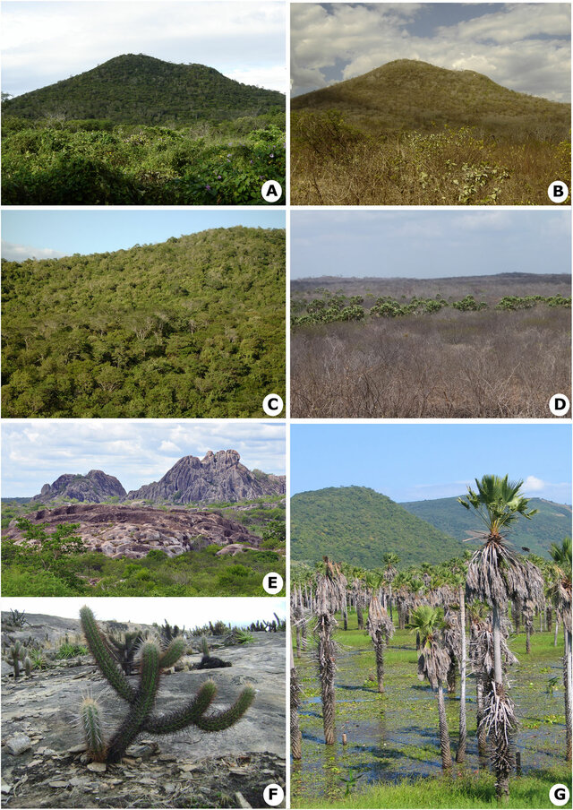

## Comparativo entre as visões

| Aspecto | Clements | Gleason |
| --- | --- | --- |
| Comunidade | Superorganismo | Assembleia casual |
| Sucessão | Determinística | Estocástica |
| Clímax | Único e fixo | Múltiplos/variável |
| Espécies | Interdependentes | Independentes |
| Previsibilidade | Alta | Baixa |

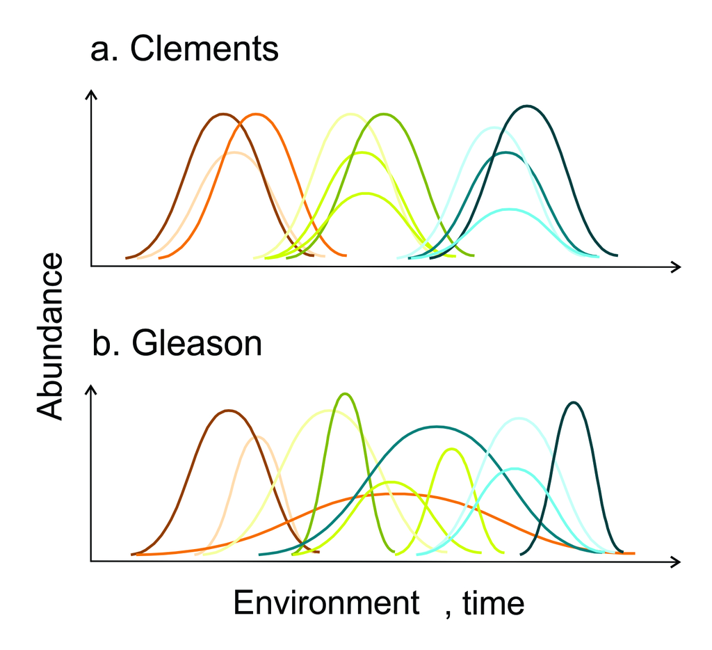

## Síntese Moderna: Filtros de Montagem

A ecologia contemporânea integra ambas as visões através do conceito de **filtros de montagem** (Assembly Rules):

#### 🌍 Filtro Abiótico

Clima, solo, água, topografia filtram o pool regional de espécies  
Ex.: solos hidromórficos do Pantanal excluem espécies não tolerantes a inundação

#### 🐾 Filtro Biótico

Competição, predação, mutualismo e facilitação determinam quem persiste  
Ex.: herbivoria de grandes mamíferos no Cerrado molda composição de gramíneas

#### 🎲 Filtro de Dispersão

Limitação de dispersão e acaso histórico completam a montagem  
Ex.: rios como barreiras de dispersão na Amazônia — hipótese dos rios

**Pool Regional** → Filtro Abiótico → Filtro de Dispersão → Filtro Biótico → **Comunidade Local**

## Estratégias de Regeneração

**r vs. K e Triângulo CSR**

## Estratégias r e K — Teoria da Seleção de História de Vida

**MacArthur & Wilson (1967) | Pianka (1970)**

**Espécies r-estrategistas** - Ambientes instáveis/perturbados - Alta taxa de reprodução, baixa longevidade - Pequeno porte, desenvolvimento rápido - Baixa competitividade

**Espécies K-estrategistas** - Ambientes estáveis/tardios - Baixa fecundidade, alta longevidade - Grande porte, maturação lenta - Alta competitividade por recursos

```
SUCESSÃO
Pioneiro ───────────────► Clímax

r ←─────────────────────► K

• Embaúba           • Castanheira
  (Cecropia spp.)     (Bertholletia excelsa)

• Vassourinha        • Jatobá
  (Baccharis spp.)    (Hymenaea courbaril)

• Capim-colonião     • Angico
  (Megathyrsus max.)  (Anadenanthera spp.)
```

No Cerrado, *Kielmeyera coriacea* (pau-santo) é K-estrategista com bulbos subterrâneos que suportam décadas de rebrota pós-fogo.

## Triângulo CSR de Grime

**J.P. Grime (1977)** — três estratégias primárias em função de **estresse** e **distúrbio**:

#### C Competidoras

- Baixo estresse, baixo distúrbio
- Crescimento rápido quando recursos abundam
- Alta aquisição de recursos
- **Ex.:** *Cedrela odorata* (cedro) — Floresta Atlântica

#### S Tolerantes ao Estresse

- Alto estresse, baixo distúrbio
- Crescimento lento, alta conservação de recursos
- Longevidade elevada
- **Ex.:** *Vellozia compacta* — campo rupestre

#### R Ruderais

- Baixo estresse, alto distúrbio
- Ciclo de vida curto, alta reprodução
- Colonização rápida
- **Ex.:** *Solanum mauritianum* — clareiras Mata Atlântica

Espécies reais ocupam posições **intermediárias** no triângulo (CS, SR, CR, CSR) — o modelo é contínuo, não categórico.

## CSR em figura

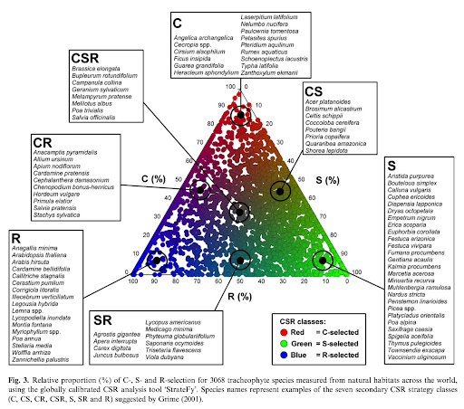

## Sucessão Primária — Colonização do Zero

**Sucessão primária** ocorre em substratos que nunca foram colonizados ou foram totalmente desprovidos de vida e solo — ausência de banco de sementes e de legado biótico.

**Etapas clássicas:**

1. **Substrato nu** — rocha, lava, dunas recentes
2. **Liquens e briófitas** — intemperismo físico-químico
3. **Herbáceas pioneiras** — acúmulo de matéria orgânica
4. **Arbustos** — sombreamento parcial
5. **Floresta** — fechamento do dossel

**Exemplos brasileiros:**

🌋 **Ilhas vulcânicas** — Trindade e Martim Vaz: colonização por *Cyperus* e fetos pioneiros sobre basalto exposto

🏖️ **Dunas costeiras** — Lençóis Maranhenses: sequência pioneira com *Ipomoea pes-caprae* → *Sophora tomentosa* → arbustos de restinga

🪨 **Inselbergs** — afloramentos rochosos no Nordeste: criptógamas → *Sedum* → vegetação rupícola

## Sucessão Secundária — Regeneração Após Distúrbio

**Sucessão secundária** ocorre onde houve uma comunidade prévia — banco de sementes, raízes, matéria orgânica e estrutura de solo permanecem, acelerando o processo.

#### ⚡ Fase Pioneira (0–5 anos)

Herbáceas, cipós e arbustos heliófilos colonizam rapidamente

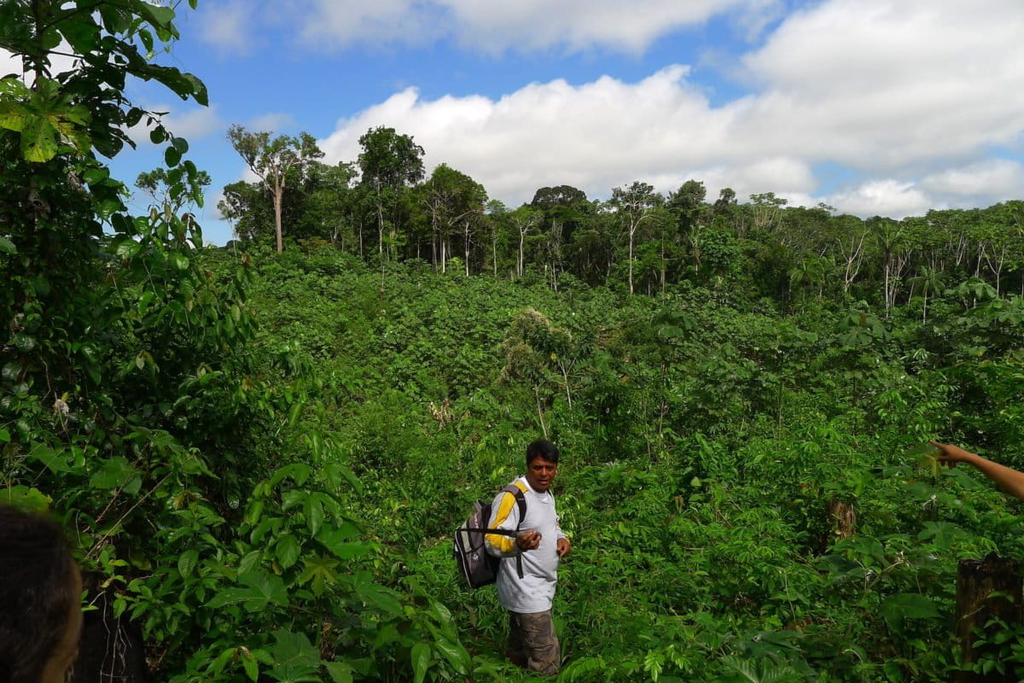

Ex.: *Cecropia*, *Trema*, *Piper* em clareiras amazônicas

#### 🌿 Fase Inicial (5–20 anos)

Árvores pioneiras formam dossel inicial; sombreamento exclui herbáceas

[figure not shown]

#### 🌳 Fase Avançada (20+ anos)

Espécies tolerantes à sombra recrutam sob o dossel; diversidade aumenta

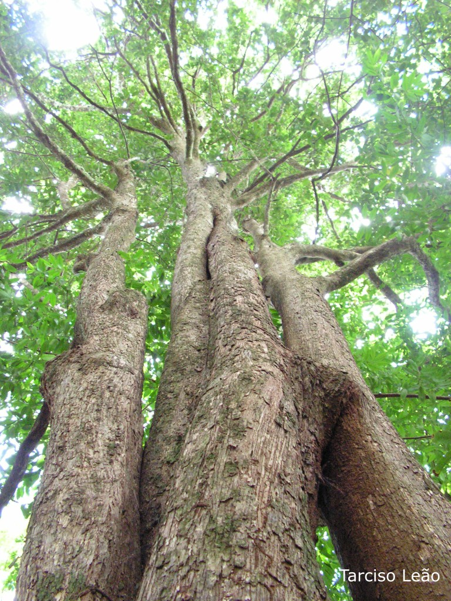

Ex.: *Euterpe oleracea*, *Eschweilera* spp. na Amazônia

## Primária vs. Secundária — Comparação

| Característica | Primária | Secundária |
| --- | --- | --- |
| Substrato | Sem solo/biota | Solo pré-existente |
| Velocidade | Muito lenta | Mais rápida |
| Banco de sementes | Ausente | Presente |
| Facilitação | Essencial | Moderada |
| Fator limitante | Nutrientes, substrato | Luz, competição |
| Duração estimada | Séculos-milênios | Décadas-século |
| Exemplo | Dunas de Lençóis | Pasto abandonado no Cerrado |

#### 📊 Velocidade de Recuperação — Mata Atlântica

Porém: **espécies raras e lianas tardias levam 200+ anos** para retornar.

## O Conceito de Distúrbio

**Distúrbio**: evento discreto no tempo que perturba a estrutura de ecossistemas, comunidades ou populações e altera recursos, disponibilidade de substrato ou ambiente físico.

#### 🔥 Intensidade

Grau de destruição da biomassa e estrutura do solo  
Baixa: queda de uma árvore  
Alta: incêndio de grandes proporções

#### 📅 Frequência

Intervalo entre distúrbios sucessivos  
Alta: campos sazonais  
Baixa: florestas de terra firme

#### 📐 Extensão

Área afetada pelo evento  
Pequena: clareiras  
Grande: queimadas de savanas

## Hipótese do Distúrbio Intermediário (HDI)

**Connell (1978):** a diversidade de espécies é maximizada em regimes de **distúrbio intermediário** — nem muito raros nem muito frequentes.

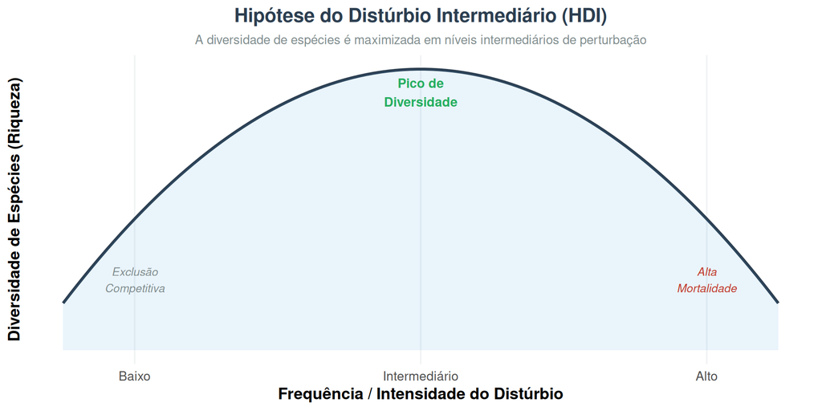

- **Baixo distúrbio:** competidores excluem espécies
- **Intermediário:** diversidade máxima
- **Alto distúrbio:** só espécies ruderais sobrevivem

**Evidências brasileiras:**

🌿 **Florestas com clareias naturais** — Floresta Amazônica mantém alta diversidade beta pelo regime de queda de árvores (0,5–2% da área/ano)

🔥 **Cerrado** — experimentos em Brasília mostram que fogo a cada 3–5 anos maximiza riqueza de gramíneas e herbáceas; fogo anual ou ausência de fogo reduzem diversidade

🌊 **Várzeas** — pulso de inundação amazônico como distúrbio intermediário chave para diversidade de peixes e macrófitas

## Distúrbios nos Biomas Brasileiros

**Distúrbios naturais:**

| Bioma | Distúrbio principal | Frequência |
| --- | --- | --- |
| Amazônia | Quedas de árvores, cheias | Contínuo |
| Cerrado | Fogo (relâmpago) | 2–5 anos |
| Pantanal | Inundação sazonal | Anual |
| Caatinga | Seca extrema | Irregular |
| Mata Atlântica | Deslizamentos, ventos | Décadas |
| Campos Sulinos | Geada, granizo | Anual |

#### ⚠️ Distúrbios antrópicos e sucessão

**Desmatamento na Amazônia:** - Corte seletivo → fragmentação → efeito de borda - Retarda ou impede sucessão secundária por: - Degradação do banco de sementes - Perda de dispersores (aves, morcegos) - Solo compactado por maquinário - “Savanização” com gramíneas exóticas

**Consequência:** Em áreas com perturbações sucessivas, a floresta secundária **não consegue se reestabelecer** sem intervenção ativa de restauração.

## Ecologia de Clareiras — Distúrbio em Escala Fina

**Clareiras (treefall gaps)** são a unidade básica de renovação florestal:

- **Área:** 20–500 m² (típico)
- **Frequência:** 0,5–2% da área florestal/ano
- Criam **mosaico** de patches em diferentes estágios

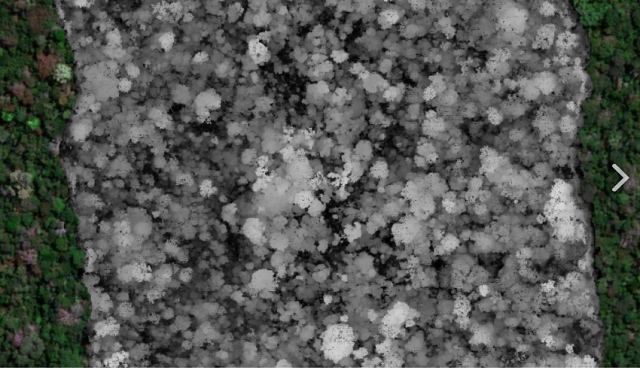

**Diferenças por tamanho de clareira:**

| Tamanho | Colonizadores | Resultado |
| --- | --- | --- |
| < 50 m² | Sub-bosque | Regeneração local rápida |
| 50–200 m² | Pioneiras mistas | Diversidade intermediária |
| > 200 m² | Heliófitas obrigadas | Alta biomassa pioneira |

Clareiras grandes (> 200 m²) na Floresta Atlântica são colonizadas preferencialmente por *Cecropia glaziovii* e *Piper* spp., gerando alta heterogeneidade espacial.

## Traços Funcionais e Dinâmica Sucessional

**Ecologia funcional** estuda como os **traços das espécies** (morfológicos, fisiológicos, comportamentais) determinam sua resposta ao ambiente e seu efeito sobre processos ecossistêmicos.

#### 🍃 Traços Foliares

- **SLA** (Área foliar específica)
- **LDMC** (teor de matéria seca)
- Concentração de N e P
- Espessura da folha

#### 🌲 Traços de Porte

- Altura máxima
- Densidade da madeira
- Diâmetro do tronco
- Espessura da casca

#### 🌰 Traços Reprodutivos

- Massa da semente
- Síndrome de dispersão
- Idade de primeira reprodução
- Fecundidade

## Gradientes Funcionais ao Longo da Sucessão

**Espécies pioneiras → tardias:**

| Traço | Pioneiras | Tardias |
| --- | --- | --- |
| SLA | Alto (folhas finas) | Baixo (esclerófilas) |
| Densidade da madeira | Baixa | Alta |
| Massa da semente | Pequena | Grande |
| Crescimento | Rápido | Lento |
| Tolerância à sombra | Baixa | Alta |
| Dispersão | Anemocoria/zoocoria pequena | Zoocoria grande |

**Gradiente exploração → conservação de recursos (Díaz et al. 2016)**

O “espectro econômico foliar” organiza espécies em um eixo de aquisição rápida (*fast*) a conservação (*slow*) de recursos — padrão universal, incluindo florestas tropicais brasileiras.

## Diversidade Funcional e Estabilidade Ecossistêmica

**Por que a diversidade funcional importa na sucessão?**

- **Redundância funcional:** múltiplas espécies com mesmo papel → resiliência
- **Complementaridade:** diferentes nichos = melhor uso dos recursos
- **Efeito de amostrador:** espécies dominantes determinam função do ecossistema

**Durante a sucessão:** - Fases iniciais: **baixa** diversidade funcional (poucas estratégias) - Fases intermediárias: **alta** diversidade funcional - Fases tardias: **diversidade** estrutural alta, funcional moderada (convergência)

#### 📌 Caso: Diversidade Funcional no Cerrado

Estudos em áreas com diferentes históricos de fogo no Cerrado de Brasília mostram que:

- **Cerrado com fogo intermediário** tem maior diversidade funcional de gramíneas (traços: altura, SLA, aerênquima)
- **Cerrado sem fogo** tende à dominância de poucas espécies lenhosas C-estrategistas
- **Fogo frequente** seleciona fortemente por traços de rebrota (geófitos, xilopódios)

→ **Regime de fogo = filtro funcional de primeira ordem**

## Facilitação e Inibição na Perspectiva Funcional

#### ✅ Facilitação

Espécies pioneiras **melhoram o ambiente** para sucessores  
Ex.: Leguminosas fixadoras de N₂ (*Inga*, *Mimosa*) aumentam fertilidade do solo na Mata Atlântica secundária, acelerando estabelecimento de tardias

#### 🚫 Inibição

Espécies estabelecidas **resistem** à invasão por sucessores  
Ex.: Gramíneas africanas (*Urochloa* spp.) em áreas de Cerrado degradado inibem regeneração de lenhosas por competição intensa e promoção de fogo

#### 🔄 Tolerância

Sucessores crescem **lentamente** sob o dossel dos pioneiros até superá-los  
Ex.: Palmeiras (*Euterpe edulis*) germinam no sub-bosque e crescem durante décadas até atingir o dossel na Mata Atlântica

## Síntese: Teoria e Padrões de Biomas Brasileiros

**Gradientes-chave que modulam a sucessão no Brasil:**

| Gradiente | Efeito na sucessão |
| --- | --- |
| Precipitação | Velocidade e complexidade |
| Sazonalidade | Caducifolia vs. perenifólia |
| Fogo | Fisionomia e traços funcionais |
| Fertilidade do solo | Biomassa e diversidade |
| Altitude | Composição florística |
| Fragmentação | Disponibilidade de propágulos |

**Convergências teóricas:**

🌿 **Gleason vence Clements** no detalhe — mas filtros abióticos fortes (seca, fogo, inundação) criam previsibilidade clementsiana em escala regional.

🔄 **CSR + r/K** são complementares: r/K descreve o eixo ciclo de vida; CSR adiciona o eixo estresse.

🔥 **Distúrbio intermediário** explica a alta diversidade dos biomas — Cerrado e Amazônia são sistemas mantidos longe do equilíbrio.

## Restauração Ecológica como Sucessão Dirigida

#### 🌱 Nucleação

Criar pontos de atração para fauna dispersora (poleiros artificiais, plantio em ilhas)  
Acelera colonização natural ao redor do núcleo — eficaz na Mata Atlântica e Cerrado

#### 🌳 Plantio em modelos mistos

Combinar espécies de diferentes grupos funcionais (pioneiras + tardias)  
Modelo CERNE/ESALQ: 30% pioneiras + 70% tardias em Mata Atlântica

#### 🔬 Restauração Funcional

Selecionar espécies por **traços funcionais** para garantir processos ecossistêmicos  
Não apenas diversidade de espécies, mas de funções (polinizadores, dispersores, fixadores de N)

**Meta do PACTO PELA RESTAURAÇÃO DA MATA ATLÂNTICA e Plano ABC+:** restaurar 15 milhões de hectares até 2030 — a maior iniciativa de restauração tropical do mundo.

## Desafios Contemporâneos

**Mudanças climáticas e sucessão:**

- Alteração do regime de chuvas → mudança nas trajetórias sucessionais
- Aumento da frequência de secas extremas na Amazônia (2005, 2010, 2015–16, 2023)
- **“Savaneização” da Amazônia:** modelo de Lovejoy & Nobre prevê ponto de inflexão entre 20–25% de desmatamento (já próximo em algumas regiões)

**Espécies exóticas invasoras:** - *Urochloa* spp. bloqueiam sucessão secundária em 50+ milhões ha no Brasil - *Hovenia dulcis* (uva-do-japão) invade sucessão tardia no Sul - Pirófitas exóticas alteram regime de fogo no Cerrado

#### 🌡️ Novos estados alternativos estáveis

A teoria dos **estados alternativos estáveis** é central para entender os biomas brasileiros sob pressão:

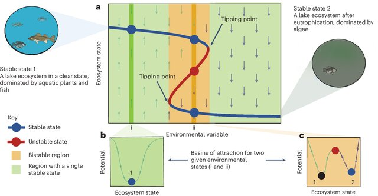

## Perspectivas e Fronteiras de Pesquisa

#### 🧬 Ecologia Molecular

Metagenômica do solo para rastrear mudanças em comunidades microbianas durante a sucessão  
Fungos micorrízicos como indicadores de estágio sucessional

#### 🛰️ Sensoriamento Remoto

Mapeamento de traços funcionais por espectroscopia hiper-espectral (AVIRIS, DESIS)  
Monitoramento de sucessão em larga escala pela variação de índices espectrais

#### 🤖 Modelos de Vegetação

Modelos dinâmicos de vegetação global (TRIFFID, JSBACH, ED2) integram traços funcionais para projetar sucessão sob cenários climáticos futuros

**Pergunta central:** Em um planeta em rápida mudança, a sucessão ecológica ainda converge para clímaxes reconhecíveis — ou os biomas brasileiros entrarão em trajetórias sem análogos históricos?

## Conceitos-Chave para Revisão

**Perguntas reflexivas:**

1. Por que o modelo de Clements ainda é útil mesmo que “errado”?
2. Como a teoria CSR e r/K se complementam?
3. O fogo no Cerrado é um distúrbio ou um componente constitutivo?
4. Por que a sucessão secundária amazônica pode ser mais lenta que a primária em algumas condições?
5. Como traços funcionais podem guiar a seleção de espécies para restauração?
6. O que os estados alternativos estáveis implicam para a conservação do Cerrado?